# Keeping it simple with R Markdown

March 20, 2015

## Overview

[figure not shown]

## When should you use Rmd?

## Rmd is an easy way to write

```r
model <- t.test(x=dat$variable.4[dat$variable.3 == 'Giants'],
                y=dat$variable.4[dat$variable.3 == 'Athletics'])
```

"An independent samples t test showed the teams were not significantly different in their number of homeruns so far this year, t = -1.0393, df = 5.8576, p = 0.3396"

| Homeruns | Giants | Athletics |
| --- | --- | --- |
| Mean | 5.2423 | 5.887 |

## Rmd is an easy way to be reproducible

[figure not shown]

## Rmd is an easy way to open access

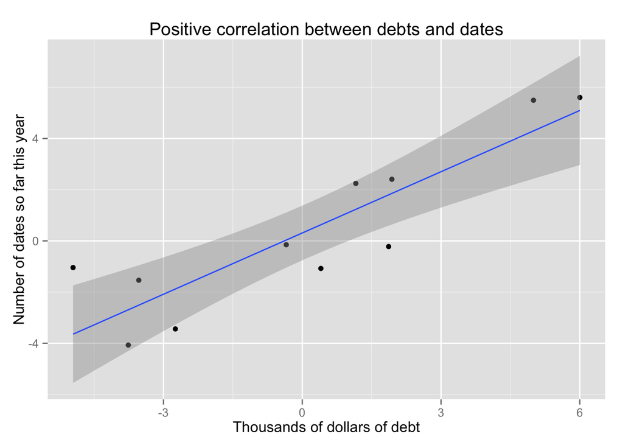

## Rmd is not good for presenting media

[figure not shown]

[A youtube link](https://www.youtube.com/watch?v=dQw4w9WgXcQ)

## How do you use R markdown?

## Basics of Rmd formatting pt 1

Chunks of code in Rmd are embedded with backticks:

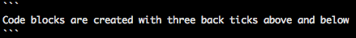

## Basics of Rmd formatting pt 2

You can evaluate the code chunk by adding {r}:

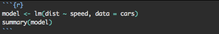

## Basics of Rmd formatting pt 3

You can suppress the code itself by adding echo=FALSE:

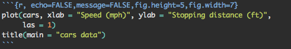

## Basics of Rmd formatting pt 3

You can evaluate code within a line by using a single backtick

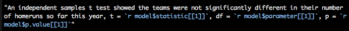

## Basics of Rmd formatting pt 4

The title of a document is separated by dashed lines:

```
Audacious title for your document and/or presentation
---
```

## Basics of Rmd formatting pt 5

Headings follow the markdown standard hierarchy, with a slight modifications for presentations

```
# Heading 1 (slide interrupt)
## Heading 2 (slide title)
### Heading 3 (subtitle)
and so on ...
```

## Basics of Rmd formatting pt 6

Text can be given basic formatting

```
*italics*
**bold**
~subscript~
^superscript^
```

## Basics of Rmd formatting pt 7

Tables are constructed with dashes and pipes, and format automatically

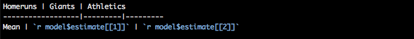

## Basics of Rmd formatting pt 8

Links and are embedded using `[name](location)` and images are embedded using `![name](location)`

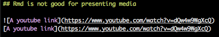

## Getting started with Rmd

## Obtaining the necessary materials

If you haven't already, go to:

github.com/deniederhut/workshop_Rmd

- Github is a website for sharing and collaborating
- You can download the code for this workshop as a .zip, or you can clone it with HTTPS or SSH
- You should see cheat sheets in Rmd and HTML, along with a data file, this presentation, and a file called your_script.R

## Getting started in RStudio

- Open the .R script by going to File/Open File and selecting your_script.R
- You will see an .R script containing the same analysis you saw in this presentation
- Open a new .Rmd document by going to New File/Markdown, and selecting Document, then HTML

## Creating your first document pt 1

- Let's start by editing `title`, `author`, and `date` to appropriate values
- If you are creating a document, these will be in the header
- If you are creating a presentation, these will become the title slide
- If you want to make a slide deck instead of a document, you can change `html_document` to `ioslides_presentation`
- Try clicking the `Knit HTML` button to see how things look so far

## Creating your first document pt 2

- The people who want to read your document probably don't need to see the basic setup stuff
- You still need to put it in your document, but can suppress it with the `echo=FALSE` option

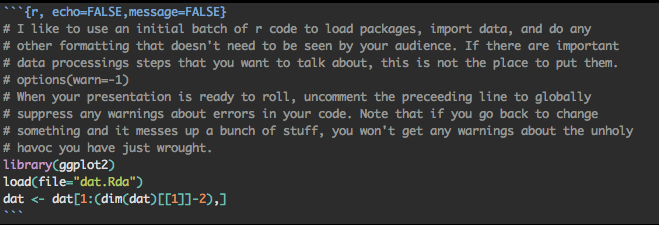

## Creating your first document pt 3

- Now let's put a little bit of basic information in your document
- You want these code chunks to echo and evaluate, so make sure you include `{r}` when you copy the code over
- We can also put graphs into your document
- Try copying over one of the `qplot` function calls in a code chunk that does not echo

## Creating your first document pt 4

- Keep copy-and-pasting the rest of the .R script into your new Rmd document
- One of the benefits of being open about your methods is that it makes it easy to catch mistakes that might significantly change your analysis
- I purposively made a small mistake when I put together this presentation
- For 10 pts extra credit:
  - Look carefully at the code I used, especially the parts that were not echoed in presentation
  - See if you can tell a different story about what the data might really mean